# Exercise: Logistic Regression

Robin Browne

March 28, 2018

### Logistic Regression

As part of our learning exercise, we are looking to perform a logistic regression on a provided dataset.

```python
import pandas as pd
import numpy as np
from sklearn import preprocessing
from sklearn.linear_model import LogisticRegression
from sklearn.model_selection import train_test_split
from sklearn.metrics import confusion_matrix
df1 = pd.read_csv("conversion_data.csv")
```

### Summarise Data

Let’s look at the data summary.

```r
  ## summary stats
  skim(py$df1) %>% skimr::kable()
```

Skim summary statistics  
n obs: 316200  
n variables: 6

Variable type: character

| variable | missing | complete | n | min | max | empty | n_unique |
| --- | --- | --- | --- | --- | --- | --- | --- |
| country | 0 | 316200 | 316200 | 2 | 7 | 0 | 4 |
| source | 0 | 316200 | 316200 | 3 | 6 | 0 | 3 |

Variable type: numeric

| variable | missing | complete | n | mean | sd | p0 | p25 | p50 | p75 | p100 | hist |
| --- | --- | --- | --- | --- | --- | --- | --- | --- | --- | --- | --- |
| age | 0 | 316200 | 316200 | 30.57 | 8.27 | 17 | 24 | 30 | 36 | 123 |  |
| converted | 0 | 316200 | 316200 | 0.032 | 0.18 | 0 | 0 | 0 | 0 | 1 |  |
| new_user | 0 | 316200 | 316200 | 0.69 | 0.46 | 0 | 0 | 1 | 1 | 1 |  |
| total_pages_visited | 0 | 316200 | 316200 | 4.87 | 3.34 | 1 | 2 | 4 | 7 | 29 |  |

### Impact of Source on Conversion

#### By New Visitors

Let’s look at conversion and new user share by country and traffic source.

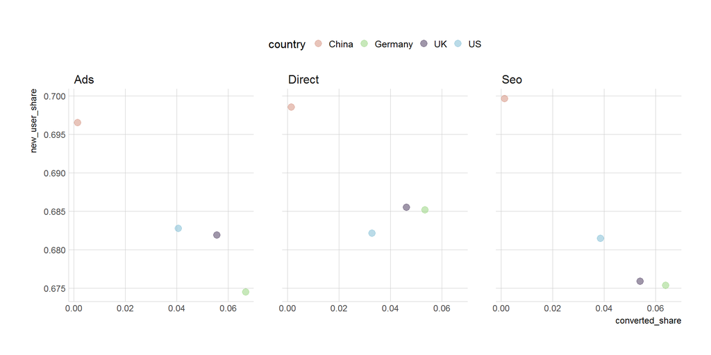

```r
  ## filter out ages above 80
  df2 <- py$df1 %>% filter(age <= 80)
  ## summarise and plot
  df2 %>%
    select(country,source,new_user,converted) %>%
    group_by(country,source) %>%
    summarise(
      users = n(),
      new_user_share = sum(new_user)/users,
      converted_share = sum(converted)/users
    ) %>%
  ggplot(aes(converted_share,new_user_share)) +
    geom_jitter(aes(color=country, fill=country), size=3, shape=21, alpha=1/2) +
    scale_color_ipsum() +
    scale_fill_ipsum() +
    facet_wrap(~source) +
    theme_ipsum_ps(grid="XY", axis="xy") +
    theme(legend.position="top")
```

#### By Pages Viewed

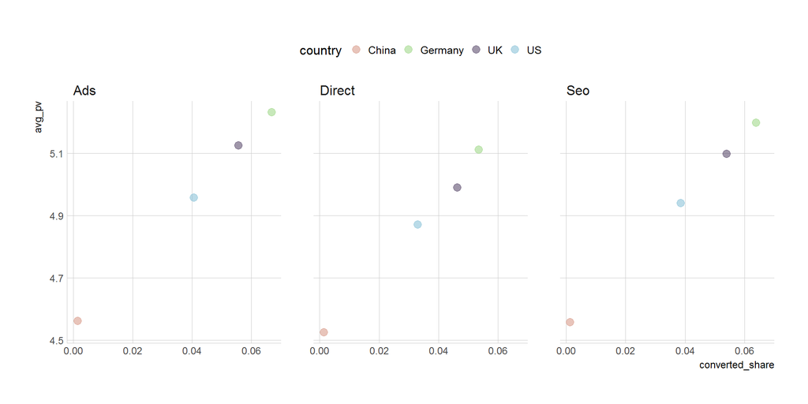

```r
  ## summarise and plot
  df2 %>%
    select(country,source,total_pages_visited,converted) %>%
    group_by(country,source) %>%
    summarise(
      users = n(),
      avg_pv = sum(total_pages_visited)/users,
      converted_share = sum(converted)/users
    ) %>%
  ggplot(aes(converted_share,avg_pv)) +
    geom_jitter(aes(color=country, fill=country), size=3, shape=21, alpha=1/2) +
    scale_color_ipsum() +
    scale_fill_ipsum() +
    facet_wrap(~source) +
    theme_ipsum_ps(grid="XY", axis="xy") +
    theme(legend.position="top")
```

### Conversion by New User

#### Age group and country

Let’s break down the data by the age groups and see performance differences.

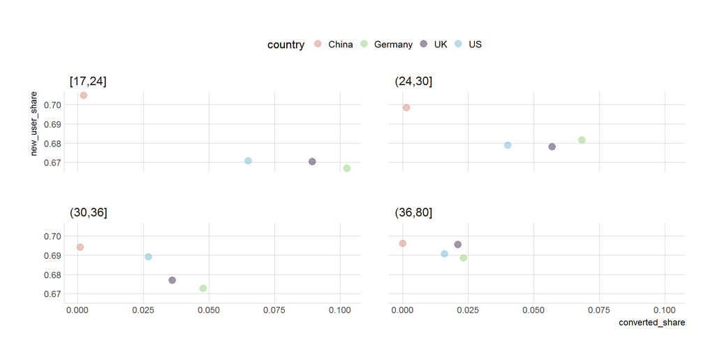

```r
## summarise by age group and plot
df2 %>%
  select(country,source,age,new_user,converted) %>%
  group_by(gr=cut(age,breaks=c(17,24,30,36,80),include.lowest= T)) %>%
  select(country,gr,converted,new_user) %>%
  group_by(country,gr) %>%
  summarise(
    users = n(),
    new_user_share = sum(new_user)/users,
    converted_share = sum(converted)/users
  ) %>%
  ggplot(aes(converted_share,new_user_share)) +
  geom_jitter(aes(color=country, fill=country), size=3, shape=21, alpha=1/2) +
  scale_color_ipsum() +
  scale_fill_ipsum() +
  facet_wrap(~gr) +
  theme_ipsum_ps(grid="XY", axis="xy") +
  theme(legend.position="top")
```

#### Age group and source

Let’s break down the data by the age groups and see performance differences.

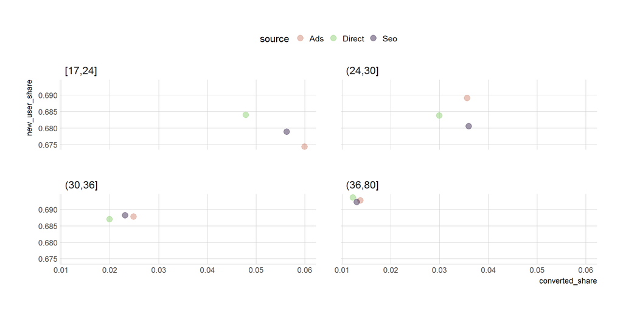

```r
## summarise by age group and plot
df2 %>%
  select(country,source,age,new_user,converted) %>%
  group_by(gr=cut(age,breaks=c(17,24,30,36,80),include.lowest= T)) %>%
  select(source,gr,converted,new_user) %>%
  group_by(source,gr) %>%
  summarise(
    users = n(),
    new_user_share = sum(new_user)/users,
    converted_share = sum(converted)/users
  ) %>%
  ggplot(aes(converted_share,new_user_share)) +
  geom_jitter(aes(color=source, fill=source), size=3, shape=21, alpha=1/2) +
  scale_color_ipsum() +
  scale_fill_ipsum() +
  facet_wrap(~gr) +
  theme_ipsum_ps(grid="XY", axis="xy") +
  theme(legend.position="top")
```

### Conversion by Pages Viewed

#### Age group and country

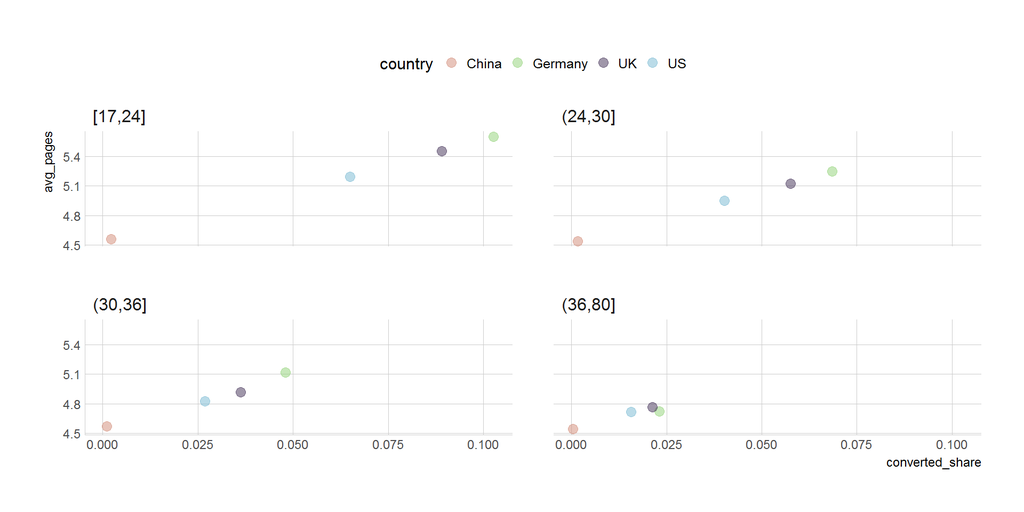

```r
df2 %>%
  select(country,source,age,new_user,converted,total_pages_visited) %>%
  group_by(gr=cut(age,breaks=c(17,24,30,36,80),include.lowest= T)) %>%
  select(country,gr,converted,total_pages_visited) %>%
  group_by(country,gr) %>%
  summarise(
    users = n(),
    avg_pages = sum(total_pages_visited)/users,
    converted_share = sum(converted)/users
  ) %>%
  ggplot(aes(converted_share,avg_pages)) +
  geom_jitter(aes(color=country, fill=country), size=3, shape=21, alpha=1/2) +
  scale_color_ipsum() +
  scale_fill_ipsum() +
  facet_wrap(~gr) +
  theme_ipsum_ps(grid="XY", axis="xy") +
  theme(legend.position="top")
```

#### Age group and source

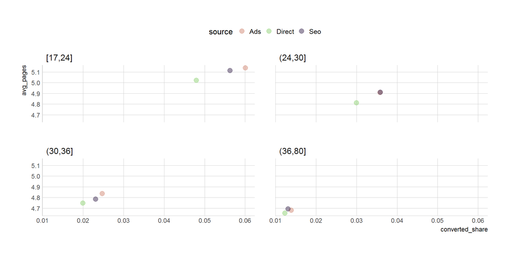

```r
df2 %>%
  select(country,source,age,new_user,converted,total_pages_visited) %>%
  group_by(gr=cut(age,breaks=c(17,24,30,36,80),include.lowest= T)) %>%
  select(source,gr,converted,total_pages_visited) %>%
  group_by(source,gr) %>%
  summarise(
    users = n(),
    avg_pages = sum(total_pages_visited)/users,
    converted_share = sum(converted)/users
  ) %>%
  ggplot(aes(converted_share,avg_pages)) +
  geom_jitter(aes(color=source, fill=source), size=3, shape=21, alpha=1/2) +
  scale_color_ipsum() +
  scale_fill_ipsum() +
  facet_wrap(~gr) +
  theme_ipsum_ps(grid="XY", axis="xy") +
  theme(legend.position="top")
```

### Bin both age and pages viewed

#### By Country

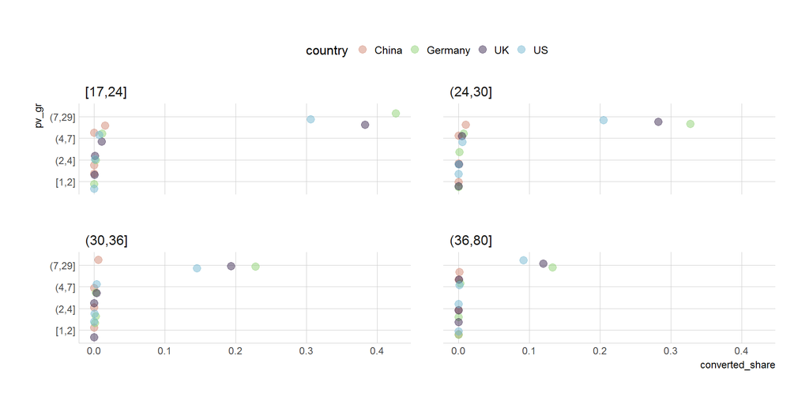

```r
## bin the age and pages
## do some binning
df2 %>%
  select(country,source,age,new_user,total_pages_visited,converted) %>%
  mutate(
    age_gr=cut(age,breaks=c(17,24,30,36,80),include.lowest= T),
    pv_gr=cut(total_pages_visited,breaks=c(1,2,4,7,29),include.lowest= T)
    ) %>%
  select(country,age_gr,pv_gr,converted) %>%
  group_by(country,age_gr,pv_gr) %>%
  summarise(
    users = n(),
    converted_share = sum(converted)/sum(users)
  ) %>%
  ggplot(aes(converted_share,pv_gr)) +
  geom_jitter(aes(color=country, fill=country), size=3, shape=21, alpha=1/2) +
  scale_color_ipsum() +
  scale_fill_ipsum() +
  facet_wrap(~age_gr) +
  theme_ipsum_ps(grid="XY", axis="xy") +
  theme(legend.position="top")
```

#### By Source

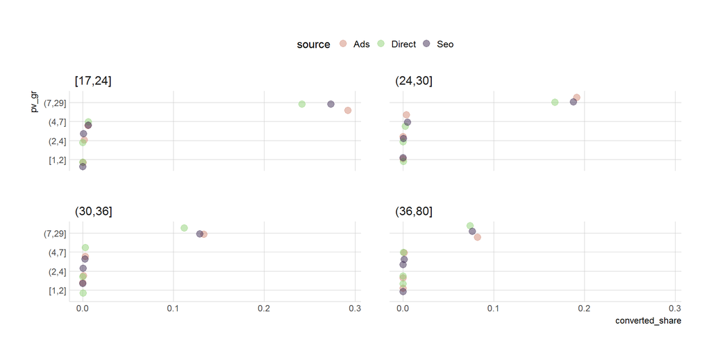

```r
 ## do the break up by source
 df2 %>%
   select(country,source,age,new_user,total_pages_visited,converted) %>%
   mutate(
     age_gr=cut(age,breaks=c(17,24,30,36,80),include.lowest= T),
     pv_gr=cut(total_pages_visited,breaks=c(1,2,4,7,29),include.lowest= T)
   ) %>%
   select(source,age_gr,pv_gr,converted) %>%
   group_by(source,age_gr,pv_gr) %>%
   summarise(
     users = n(),
     converted_share = sum(converted)/sum(users)
   ) %>%
   ggplot(aes(converted_share,pv_gr)) +
   geom_jitter(aes(color=source, fill=source), size=3, shape=21, alpha=1/2) +
   scale_color_ipsum() +
   scale_fill_ipsum() +
   facet_wrap(~age_gr) +
   theme_ipsum_ps(grid="XY", axis="xy") +
   theme(legend.position="top")
```

```r
  df3 <- df2 %>%
  select(country,source,age,new_user,total_pages_visited,converted) %>%
  mutate(
    age_gr=cut(age,breaks=c(17,24,30,36,80),include.lowest= T),
    pv_gr=cut(total_pages_visited,breaks=c(1,2,4,7,29),include.lowest= T)
    ) %>%
  select(-total_pages_visited,-age,-new_user)
```

## Feature Selection

Looks like pages viewed, age group, countries are the biggest predictors of conversion. We will now create dummy variables for them.

```python
## do some dummy data creation
df4 = pd.get_dummies(data=r.df3, columns=['country', 'source','age_gr','pv_gr'])
```

**The dummy variable column names are:** *converted, country_China, country_Germany, country_UK, country_US, source_Ads, source_Direct, source_Seo, age_gr_[17,24], age_gr_(24,30], age_gr_(30,36], age_gr_(36,80], pv_gr_[1,2], pv_gr_(2,4], pv_gr_(4,7], pv_gr_(7,29]*

### Do some model building

Remove converted from dataset, and put converted in its own dataframe.

```python
# remove converted column
X=df4.loc[:, df4.columns != 'converted']
# create only converted df
Y=df4['converted']
```

**Shape of X Dataset:** 316198 rows and 15 columns.

**The columns names for X are:** *country_China, country_Germany, country_UK, country_US, source_Ads, source_Direct, source_Seo, age_gr_[17,24], age_gr_(24,30], age_gr_(30,36], age_gr_(36,80], pv_gr_[1,2], pv_gr_(2,4], pv_gr_(4,7], pv_gr_(7,29]*

### Split into train and test

70:30 split of data into train and test.

```python
#Split the data into training and test data (70/30 ratio)
X_train,X_test,Y_train,Y_test=train_test_split(X,Y,test_size=0.3, random_state=100, stratify=Y)
Conv_Train = np.sum(Y_train)
Conv_Test = np.sum(Y_test)
```

**Shape of X Train:** 221338 rows and 15 columns

**Shape of X Test:** 94860 rows and 15 columns

**Shape of Y Train:** 221338 rows

**Shape of Y Test:** 94860 rows

```python
#Build logisitic regression model and train it on training dataset
logreg = LogisticRegression(class_weight='balanced').fit(X_train,Y_train)
#Test the model on test dataset
pred_logreg=logreg.predict(X_test)
confusion = confusion_matrix(Y_test, pred_logreg,)
print("Confusion matrix:\n{}".format(confusion))
```

```
## Confusion matrix:
## [[81364 10437]
##  [  135  2924]]
```

Out of 3059 converted users in test dataset, the model was correctly able to predict 2924. So, a *success rate* of about 95.6%

```python
from sklearn.metrics import roc_auc_score
logreg_auc = roc_auc_score(Y_test, logreg.predict_proba(X_test)[:, 1])
print("AUC for Logistic Regression: {:.3f}".format(logreg_auc))
```

```
## AUC for Logistic Regression: 0.953
```

```python
from sklearn.metrics import classification_report
print(classification_report(Y_test, pred_logreg,
                            target_names=["Non Converted", "Converted"]))
```

```
##                precision    recall  f1-score   support
##
## Non Converted       1.00      0.89      0.94     91801
##     Converted       0.22      0.96      0.36      3059
##
##   avg / total       0.97      0.89      0.92     94860
```